# 03 In-Class Assignment: Solving Linear Systems of equations

In the movie Groundhog day the main character "Phil" repeats the same day over and over again. This is an iterative process where Phil learns from past mistakes until he has a "perfect" day. The Groundhog movie is a fun analogy of iterative methods for solving linear equations. In this class we will write our own iterative method.

## 1. Pre-class assignment review

We will discuss

- Row form of a system of linear equations and its graphical interpretation in $\mathbb R^2$ and $\mathbb R^3$
- Column form of a system of linear equations and its graphical interpretation
- Matrix notation, matrix-vector multiplication
- Matrix form of a system of linear equations

## 2. Linear System Example :

Suppose that we have three objects on a balanced beam. Also suppose we know that one has a mass of 2 kg, and we want to find the two unknown masses. Experimentation with a (assume weightless) meter stick produces these two balances. (diagram not to scale)

[figure not shown]

For the masses to balance we must have the sum of the moments on the left equal to the sum of the moments on the right, where the moment of an object is its mass times its distance from the balance point. That gives a system of two equations:

$$ 40A + 15B = 50 \times 2$$$$25B = 25 \times 2 + 50A$$

✅ **Do This:** Rewrite the above system in row, column, and matrix form.

$$ 40A + 15B = 50 \times 2$$$$25B - 50A = 25 \times 2 $$

$$ a \left[ \begin{matrix} 40 \\ -50 \end{matrix} \right] + b \left[ \begin{matrix} 15 \\ 25 \end{matrix} \right] = \left[ \begin{matrix} 100 \\ 50 \end{matrix} \right] $$

$$ \left[ \begin{matrix} 40 & 15 \\ -50 & 25 \end{matrix} \, \middle\vert \, \begin{matrix} 100 \\ 50 \end{matrix} \right] $$

✅ **Do This:** Find a solution for the above systems of equations and place your solution in the following cell. Make sure you delete the instructional text in the cell first.

a = 1 and b = 4

✅ **Do This:** Using Python as a calculator, verify that the solution you have found is correct.

```python
25*(4) - 50*(1) == 50
40*(1) + 15*(4) == 100
```

```
True
```

✅ **Do This:** Now let's consider a system where we have three unknown masses instead of two. Experimentation with a meter stick produces the two balanced states shown below (diagram not to scale). Write the equations for this system.

[figure not shown]

35A + 21B = 11C + 50*2

25C = 10A + 24B + 50*2

✅ **Do This:** Rewrite the above system in row, column, and matrix form.

$$ 35A + 21B = 11C + 50 \times 2$$$$25C = 10A + 24B + 50 \times 2 $$

$$ a \left[ \begin{matrix} 35 \\ -10 \end{matrix} \right] + b \left[ \begin{matrix} 21 \\ -24 \end{matrix} \right] + c \left[ \begin{matrix} -11 \\ 25 \end{matrix} \right] = \left[ \begin{matrix} 100 \\ 100 \end{matrix} \right] $$

✅ **Do This:** Find a solution to the second set of equations and report the mass for objects A, B and C. Note that there are many possible solutions.

A = 371/85 B = 1 C = 114/17

✅ **Do This:** Using Python as a calculator, verify that the solution you have found is correct.

```python
round(35*(371/85) + 21*1 - 11*(114/17)) == 100

round(25*(114/17) - 10*(371/85) - 24*1) == 100
```

```
True
```

## 3. Jacobi Method for solving Linear Equations

During class today we will write an iterative method (named after Carl Gustav Jacob Jacobi) to solve the following system of equations:

$$ 6x + 2y - ~z = 4~$$$$~ x + 5y + ~z = 3~$$$$ 2x +~ y + 4z = 27$$

Here is a basic outline of the Jacobi method algorithm:

1. Initialize each of the variables as zero ($x_0 = 0, y_0 = 0, z_0 = 0$)
2. Calculate the next iteration using the above equations and the values from the previous iterations. For example here is the formula for calculating $x_i$ from $y_{(i-1)}$ and $z_{(i-1)}$ based on the first equation: $$x_i = \frac{4 - 2y_{(i-1)} + z_{(i-1)}}{6} $$ Similarly, we can obtain the update for $y_i$ and $z_i$ from the second and third equations, respectively.
3. Increment the iteration counter $(i = i + 1)$ and repeat Step 2.
4. Stop when the answer "converges" or a maximum number of iterations has been reached. (ex. $i$ = 100)

**IMPORTANT NOTE:**

> A sufficient (but not necessary) condition for the method to converge is that the matrix A is strictly or irreducibly [diagonally dominant](https://en.wikipedia.org/wiki/Diagonally_dominant_matrix). Strict row diagonal dominance means that for each row, the absolute value of the diagonal term is greater than the sum of absolute values of other terms. - From [Wikipedia](https://en.wikipedia.org/wiki/Jacobi_method)

In other words, the Jacobi Methid will not work an all problems.

✅ **DO THIS:** Write out the equations for $x_i$, $y_i$, and $z_i$ based on $x_{(i-1)}$, $y_{(i-1)}$, and $z_{(i-1)}$.

$$x_i = \frac{4 - 2y_{(i-1)} + z_{(i-1)}}{6} $$$$y_i = \frac{3 - x_{(i-1)} - z_{(i-1)}}{5} $$$$z_i = \frac{27 - 2x_{(i-1)} - y_{(i-1)}}{4} $$

✅ **DO THIS:** Complete the following code by adding formulas for $y_i$ and $z_i$ to solve the above equations using the Jacobi method.

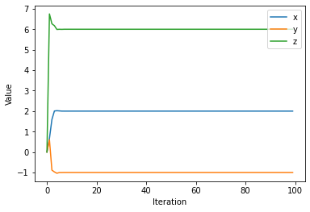

```python
%matplotlib inline
import matplotlib.pylab as plt

x = []
y = []
z = []

#step 1: inicialize to zero
x.append(0)
y.append(0)
z.append(0)

for i in range(1,100):
    xi = (4 - 2*y[i-1]+ z[i-1])/6
#####Start your code here #####
    yi = (3 - x[i-1]- z[i-1])/5 #Change this line
    zi = (27 - 2*x[i-1]- y[i-1])/4 #Change this line
#####End of your code here#####
    #Add latest value to history
    x.append(xi)
    y.append(yi)
    z.append(zi)

#Plot History of values
plt.plot(x, label='x')
plt.plot(y, label='y')
plt.plot(z, label='z')
plt.xlabel('Iteration')
plt.ylabel('Value')
plt.legend(loc=1);
```

✅ **QUESTION:** What are the final values for $x$, $y$, and $z$?

$$x = 2$$$$y = -1$$$$z = 6$$

✅ **DO THIS:** Write out each of the above equations and show that your final result is a solution to the system of equations:

```python
6*2 + 2*(-1) - 6 == 4
2 + 5*(-1) + 6 == 3
2*2 + (-1) + 4*6 == 27
```

```
True
```

✅ **QUESTION:** By inspecting the graph, how long did it take for the algorithum to converge to a solution?

✅ **QUESTION:** How could you rewrite the above program to stop earlier.

instead of doing for i in range (1,100) you could do in range 10 to show the change of i more clearly while having a smaller y range.

## 4. Numerical Error

Consider the following python statement when answering the questions below:

```python
0.1 + 0.2 == 0.3
```

```
False
```

```python
a = 0.1 + 0.2
print(a)
```

```
0.30000000000000004
```

✅ **QUESTION:** Why does Python return **False** even though the above statement is clearly true?

because the computer does not see those values as summing to exactly 0.3. I did an example of this below to test out what python actually determines is the sum of those values and it clearly continues to round for many values making it not equal to 0.3. This can easily be fixed with the python round() function.

✅ **DO THIS:** Let's consider another example. Run the following code which should return true.

```python
import numpy as np
J = np.array([20])
L = [20]

pow(L[0],8) == pow(J[0],8)
```

```
True
```

If you have an older version of `numpy` installed (like 1.18.5) then the results of running the above cell may be false (did anyone get this result?). This is because `numpy` changed how it handles something called "roundoff error". here is another cell that may help you see better what is going on:

```python
import numpy as np
J = np.array([20])
L = [20]
print(pow(20,8))
print(pow(L[0],8))
print(pow(J[0],8))
```

```
25600000000
25600000000
25600000000
```

The older version of `numpy` would return the following:

```
25600000000
25600000000
-169803776
```

We could say to always upgrade to the latest stable version (generally a good idea). But some other libraries that depend on numpy may not be up to date so sometimes python will install an older version to maintain compatibility. For example, one really popular program is tensorflow, which often requires an older version of numpy.

✅ **QUESTION:** If Python is sometimes wrong, why do we use it?

Because we can figure out how to make sure python is right. It is not thinking as a human it is doing what we program it to do so if we program it to round as we would like it to then it will give us the correct answer.

✅ **QUESTION:** What are ways you can do to watch out for these types of errors?

Solving it using numbers and using python just to confirm instead of always solving. Learning ways to round values so that it does give you a value you are looking for. Another way would be to check if it equals what you assume it will equal and if it prints false then rounding the number or giving the expression a variable and printing the variable to see how python went about solving the function.

✅ **QUESTION:** Modify the following program to return **True** if the values are within some small number (`e`) of each other.

```python
def checktrue(a,b,e=0.001):
    if abs(a-b)>e:
        return True
    return False

#Test function
checktrue(round(0.1 + 0.2), 0.3)
```

```
True
```

✅ **QUESTION:** What is a good value to set for `e` and why?

the value we were given which was 0.001 is the best value to set for e because it is going to iterate enough times to show us how the value changes over very small iterations

✅ **QUESTION:** The errors seen in this example seem like they would be fairly common in Python. See if you can find a function in `Numpy` that has the same purpose as `checktrue`:

np.isclose() is a function in numpy that checks if all array elements along a given axis are true which is the same purpose as the checktrue function.

The class `answercheck` program will take into consideration round off error. For example, the `checkanswer.float` command would consider both of the above correct:

```python
from answercheck import checkanswer

checkanswer.float(0.300,'e85b79abfd76b7c13b1334d8d8c194a5');
```

```
Testing 0.3
Answer seems to be correct
```

```python
checkanswer.float(0.1+0.2,'e85b79abfd76b7c13b1334d8d8c194a5')
```

```
Testing 0.3
Answer seems to be correct
```

Written by Dr. Dirk Colbry, Michigan State University  
This work is licensed under a [Creative Commons Attribution-NonCommercial 4.0 International License](http://creativecommons.org/licenses/by-nc/4.0/).

### Congratulations, we're done!

If you attend class in-person then have one of the instructors check your notebook and sign you out before leaving class. If you are attending asynchronously, turn in your assignment using D2L.